# Como a óptica influenciou a ciência: o telescópio

Luiz Antônio Rangel

# 1.0. Introdução

Esse trabalho busca aprofundar no estudo da óptica a fim de mostrar, com base na história, como a mesma influenciou diretamente na ciência e na tecnologia, usando o telescópio como caso de estudo.

# 1.1. Introduzindo a óptica

Irei aqui introduzir brevemente o conteúdo de óptica, para entendimento prévio de conceitos básicos que serão introduzidos posteriormente. A óptica é considerada um gigantesco avanço para a humanidade pois, com exceção de nossos olhos e memória, foi totalmente descoberta e depois teve ferramentas baseadas em tal inventadas por nós.

[figure not shown]

Fonte: alamy.com

A memória (fotográfica) artificial no caso é outra história diferente, pois seria introduzida posteriormente (e rudimentarmente) pela primeira vez em 1802, pelo químico britânico Thomas Wedgwood e seu colega Humphry Davy em um informe chamado *“An Account of a method of copying Paintings upon Glass, and of making Profiles, by the Agency of Light upon Nitrate of Silver”*, onde os dois descrevem o processo de se “gravar” silhuetas e sombras em superfícies cobertas com uma solução de nitrato de prata dissolvido em água (proporção $\frac{1}{10}$).  
75 anos antes, em 1727, o professor alemão Johann Heinrich Schulze já havia conseguido “gravar” algumas palavras, mas usando uma solução diferente da de Wedgwood e Humphry, sendo esta baseada em giz, nitrato de prata e ácido nítrico.  
Digo “gravar” entre aspas pois, em ambos os casos citados (e como descrito no informe de Davy), a imagem iria descolorir em alguns momentos caso não fosse mantida em um ambiente completamente sem luz.

> “The copy of a painting, or the profile immediately after being taken, must be kept in an obscure place. It may indeed be examined in the shade, but in this case the exposure should be only for a few minutes; by the light of candles or lamps, as commonly employed, it is not commonly affected.  
> No attempts that have been made to prevent the uncoloured parts of the copy, or profile, from being acted upon by light, have as yet been successful.” (DAVY, HUMPHRY, 1802; Pg. 242)

[figure not shown]

Fonte: Wikimedia Commons, *upado* em 9 de maio de 2010

## 1.1.0. O que é a óptica?

A óptica é um dos seis ramos da física que estuda fenômenos envolvendo a luz e a visão. Em contraste a alguns outros ramos das ciências exatas, onde o conteúdo não é exatamente visível, a óptica é literalmente o que se diz ao estudo do mundo visível. Alguns conceitos podem ser entendidos com o auxílio de um laser, para se ter uma ideia.

Um breve fato curioso sobre a óptica, citado no começo do primeiro capítulo de *“Óptica Moderna: Fundamentos e Aplicações”* do Drº Sérgio Carlos Zillo, é que há uma analogia entre ela e a mecânica quântica; em que, no estado estacionário, ambas seriam descritas pela mesma equação de ondas, além de alguns princípios/teoremas, como o princípio da incerteza de Heisenberg, poderem ser provados usando experimentos ópticos — no caso do princípio da incerteza de Heisenberg, seria possível prová-lo a partir de um experimento envolvendo a difração da luz — ou seja, o entendimento da mecânica quântica se torna mais simples e menos abstrato se entendermos a óptica antes.  
Essa obra do Drº Zillo é, de fato, muito interessante; posteriormente pretendo tirar algum tempo para lê-la.

## 1.1.1. O que é a luz?

> “E disse Deus: Haja luz; e houve luz.”  
> - Gênesis 1:3

Historicamente, a definição de luz já foi teorizada diversas vezes por filósofos desde o século V a.C.; começando por Empédocles que, baseado na sua crença de que tudo no Universo seria feito a partir de quatro elementos, acreditava na ideia de que a deusa Afrodite havia criado o olho humano a partir dos tais quatro elementos e que então havia acendido uma chama que faria da visão algo possível ao permitir que o olho fosse uma fonte de luz — o que caiu por terra, pois se isso fosse verdade, então o olho humano poderia capturar imagens tanto de dia quanto à noite; ao pensar nisso, Epédocles propôs uma interação — como se fossem retas se ligando — entre os raios de luz emitidos pelos olhos e os raios de luz emitidos por outra fonte, como o próprio Sol, por exemplo.  
Em 300 a.C, Euclides escreveu *“Optica”*, obra onde estudou a luz, documentou e estudou matematicamente suas propriedades — em que questiona se o fenômeno da visão realmente seria resultado da interação de raios proposta anteriormente por Empédocles, ao apontar o fato de conseguir ver as estrelas imediatamente após piscar os olhos — ou seja, interrompendo o raio que sairia de seu olho e faria a interação, sem nenhum tipo de “*delay*” (como normalmente se esperaria de um objeto em movimento, ou de uma perturbação mecânica no ambiente como o próprio som) — a partir desse questionamento, Euclides formulou duas ideias: ou os raios emitidos pelo olho teriam velocidade positiva infinita ou a hipótese de Empédocles estava simplesmente equivocada.

Em 55 a.C., Lucrécio escreveu em *“De rerum natura”* que a “luz seria compostas de mínusculos átomos que, quando”empurrados”, não perdem tempo em se disparar através do espaço na direção de seu “empurrão”“.  
Infelizmente não sei ler latim e nem grego, então vou ficar devendo o trecho exato da obra.  
Essa teoria foi percursora da ideia de fótons, que iria ser proposta e reforçada por vários filósofos e cientistas, até ser derrubada pela teoria de ondas em 1678, 1733 anos depois, formulada e publicada inicialmente pelo polímata Christiaan Huygens em seu informe *“Traité de la lumière”* — como não falo francês, também ficarei devendo os trechos exatos em que Huygens faz e sustenta essa ideia, *excusez-moi* — e posteriormente sustentada pelo experimento do físico britânico Thomas Young, apresentado em seu informe *“On the theory of light and colours”* em que a luz apresentaria características ondulatórias como a difração e também seria uma onda transversal.

Nesta obra, ele também propõe que a visão seria composta principalmente de três cores, que seriam “canais nervosos” nos olhos — o que futuramente iria ser, ao lado do triângulo de cores de Maxwell, base para o padrão RGB, que é amplamente usado na eletrônica — principalmente na informática — nos dias atuais.

> “Since, for the reason here assigned by Newton, it is probable that the motion of the retina is rather of a vibratory than of an undulatory nature, the frequency of the vibrations must be dependent on the constitution of this substance. Now, as it is almost impossible to conceive each sensitive point of the retina to contain an infinite number of particles, each capable of vibrating in perfect unison with every possible undulation, it becomes necessary to suppose the number limited, for instance to the three principal colours, red, yellow, and blue, of which the undulations are related in magnitude nearly as the numbers 8, 7, and 6; and that each of the particles is capable of being put in motion less or more forcibly, by undulations differing less or more from a perfect unison; […]” (YOUNG, THOMAS, 1801, Pg. 19, 20)

Young também fala sobre a opinião de Newton sobre o calor, em que consistiria em vibração de partículas de um corpo, dizendo que foi negada com pouca base e que possivelmente iria ter sua popularidade recuperada:

> “It was long an established opinion, that heat consists in vibrations of the particles of bodies, and is capable of being transmitted by undulations through an apparent vacuum. (Newt. Opt. Qu. 18.) This opinion has been of late very much abandoned. Count Rumford, Professor Pictet, and Mr. Davy, are almost the only authors who have appeared to favour it; but it seems to have been rejected without any good grounds, and will probably very soon recover its popularity.” (YOUNG, THOMAS, 1801, Pg. 32)

E, “encurtando” todo o caminho matemático, histórico e teórico percorrido por Young em seu informe, cá está a conclusão de que a luz é uma onda — ou, como ele chama, ondulações.

> “This proposition is the general conclusion from all the pre ceding; and it is conceived that they conspire to prove it in as satisfactory a manner as can possibly be expected from the nature of the subject. It is clearly granted by Newton, that there are undulations, yet he denies that they constitute light; but it is shown in the three first Corollaries of the last Proposi tion, that all cases of the increase or diminution of light are referable to an increase or diminution of such undulations, and that all the affections to which the undulations would be liable, are distinctly visible in the phenomena of light; it may there fore be very logically inferred, that the undulations are light.” (YOUNG, THOMAS, 1801, Pg. 44, 45)

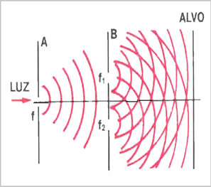

Fonte: Brasil Escola

A ideia de que a luz seria uma onda serviu de base para os estudos do físico britânico James Clerk Maxwell, que mostraram que a luz seria uma onda eletromagnética e que foram publicados em sua obra *“A Dynamical Theory of the Electromagnetic Field”*, ao lado de outras descobertas extremamente importantes na área do eletromagnetismo, como a das leis do eletromagnetismo.

> “The agreement of the results seems to show that light and magnetism are affections of the same substance, and that light is an electromagnetic disturbance propagated through the field according to electromagnetic laws.” (MAXWELL, JAMES, 1865, Pg. 499)

Nessa explicação eu pulei muita história e várias teorias que surgiram ao longo dos anos, a fim de pegar as teorias mais relevantes.

## 1.1.2. “Um pulinho em Junho”: redefinindo o conceito de ondas

*Eu pensei que fosse interessante “refrescar a memória” no que se diz ao conteúdo de ondas, sobre qual escrevi um “mini-informe” em Junho de 2021, por conta do contexto deste trabalho — admito que parte também é ego, o que faz parte, para bem ou para o mal, de todo acadêmico.*

### Definição

A onda é a propagação de um movimento — ou melhor dizendo, de sua energia — no ambiente com uma velocidade constante. Por ser apenas uma propagação de energia, uma perturbação no ambiente, uma onda nunca transportará nada, **absolutamente nada**, além de enegia.  
Uma onda pode ser definida vetorialmente a partir das seguintes variáveis:

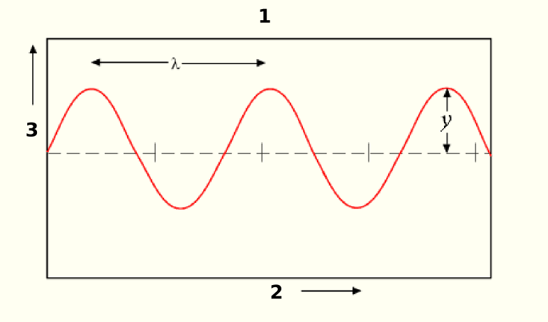

Fonte: *"Ondas: definição e demonstração"*, Rangel, Luiz Antônio *et* Bertolucci, Antônio, 2021

### Meios de propagação

- Eletromagnético:
  - Resultado de um “casamento” entre um campo magnético e um campo elétrico; não dependem de um meio físico propriamente dito (eg.: ar).
- Mecânico:
  - Resultado de uma perturbação física (mecânica) no ambiente, logo, para haver perturbação mecânica, precisa-se de algum meio físico que possa ser perturbado (eg.: ar (de novo)).

#### Direções de propagação

- Longitudinal:
  - Paralelo à perturbação. Ondas sonoras (mecânicas) se propagam paralelamente à sua perturbação.
- Transversal:
  - Perpendicular à perturbação. Ondas de choque (mecânicas) e ondas de luz (segundo Young) se propagam perpendicularmente à sua perturbação.

### Dimensões

- Unidimensionais;
  - A energia se propaga em uma única direção no ambiente, de forma linear.
- Bidimensionais;
  - A energia se propaga em duas direções, em um plano.
- Tridimensionais;
  - A energia se propaga em três direções, em um espaço tridimensional — que, geralmente, é representado como uma esfera.

### Fenômenos

- Difração
  - A onda contorna um obstáculo, como uma parede por exemplo.  
    Entretanto, como não existe almoço grátis, ela perde sua intensidade.
- Reflexão
  - A onda faz o movimento inverso, sem perder nenhuma propriedade, apenas invertendo sua direção.
- Refração
  - A velocidade da onda difere — geralmente a causa para isso é a densidade do meio — o que causa uma distorção.
- Ressonância
  - A onda entra em contato com um corpo em vibração igual ou semelhante, resultando na absorção da onda pelo dito corpo, o que consequentemente aumenta sua vibração interna.

# 2.0. O telescópio

## 2.0.1. O que é?

O telescópio é um instrumento óptico criado com a finalidade de se observar objetos distantes do observador com tamanho maior; geralmente é usado dentro da astronomia, para a observação de astros.

## 2.0.2. Um pouco de contexto histórico

O uso de prévio de lentes para ampliar corpos já era feito desde a época da Grécia antiga, mas o primeiro registro de algo próximo de um telescópio foi feito em 1608, a partir de uma patente feita por Hans Lippershey, um fabricante de lentes dos Países Baixos, que consistia de se usar duas lentes em série para aumentar objetos distantes. A ideia originalmente não era dele, mas sim de um aprendiz que percebeu que, quando colocava duas lentes em série, conseguia ver objetos distantes de perto.

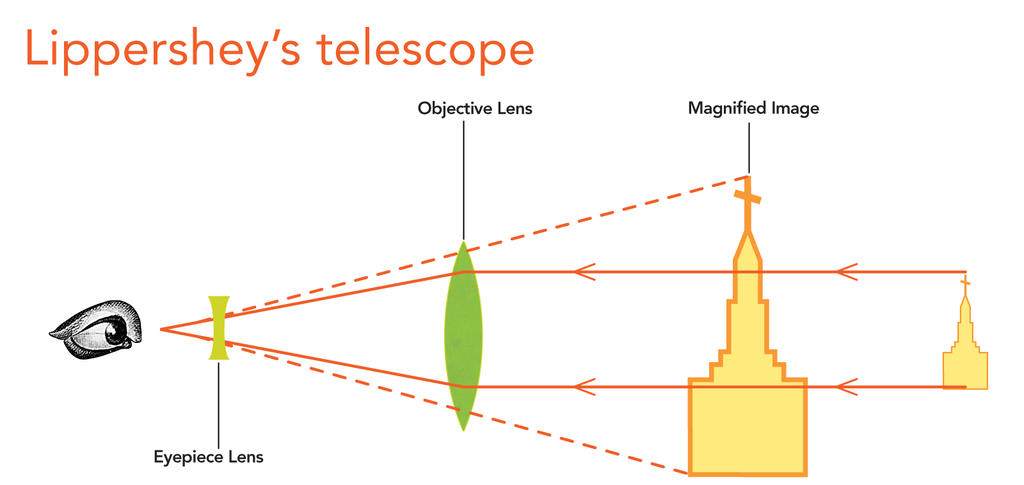

Fonte: Corning Museum of Glass

Por ser algo muito, digamos, direto de se fazer e resultado de um verdadeiro simples posicionamento, Lippershey acabou não só por não ter direito à patente como também foi acusado de plágio por seus concorrentes locais, entre eles Zacharias Janssen, que afirmou, após a publicação da ideia do telescópio como sendo de Lippershey, ter criado uma ferramenta similar quatro anos antes, em 1604.

Inicialmente o telescópio não era pensado como uma ferramenta para o estudo de astros, mas sim como uma ferramenta para se visualizar coisas distantes — inclusive, Lippershey teria vendido-os inicialmente para o governo holandês, como uma ferramenta militar.

Um ano após a publicação do “invento” de Lippershey, em 1609, o físico e astrônomo italiano Galileu Galilei decidiu fabricar seu próprio telescópio, que no final acabou por ter uma funcionalidade superior ao de Lippershey, podendo ampliar aproximadamente o triplo do que o modelo de Lippershey em sua “primeira versão”.

Com isso, ele conseguiu o respeito dos oficiais da cidade-Estado de Veneza e dos acadêmicos da Universidade de Padua. Além disso, como já se é conhecido, Galileu também estudou os astros e foi o primeiro a de fato provar que o modelo geocêntrico estaria errado, o que levou à sua perseguição pela Igreja Católica na época — o que é, de certa forma, decepcionante se lembrarmos que Galileu nunca negou a existência de Deus, inclusive defendia que a ciência humana e Deus deveriam andar juntos, afinal um seria a tentativa de entender a criação de outro.

[figure not shown]

Fonte: Desconhecida; possivelmente Domínio Público

Um ano após Galileu ter fabricado seu telescópio, em 1610, o matemático alemão Johannes Kepler ganhou um telescópio e, mesmo não tendo aptidão em engenharia (e estando com baixa visão) para montar um do zero, Kepler sabia o que podia ser melhorado ou não. Rapidamente, várias melhoras foram propostas por ele e aplicadas.  
Kepler teve uma ideia de se montar um telescópio mais longo, com uma lente ocular convexa junto com uma lente objetiva também convexa. A ideia dele permitia que houvesse um maior campo de visão e ampliação do que a ideia de Galileu original, a única desvantagem era o fato da imagem estar de ponta-cabeça, mas se tratando do céu não era um problema, afinal os planetas e satélites naturais são simétricos.

Os telescópios, todavia, ainda tinham diversos problemas que seriam eventualmente corrigidos, um deles era a aberração cromática, onde a luz sofre diferença de refração entre as lentes, ou seja, as cores se dispersam.

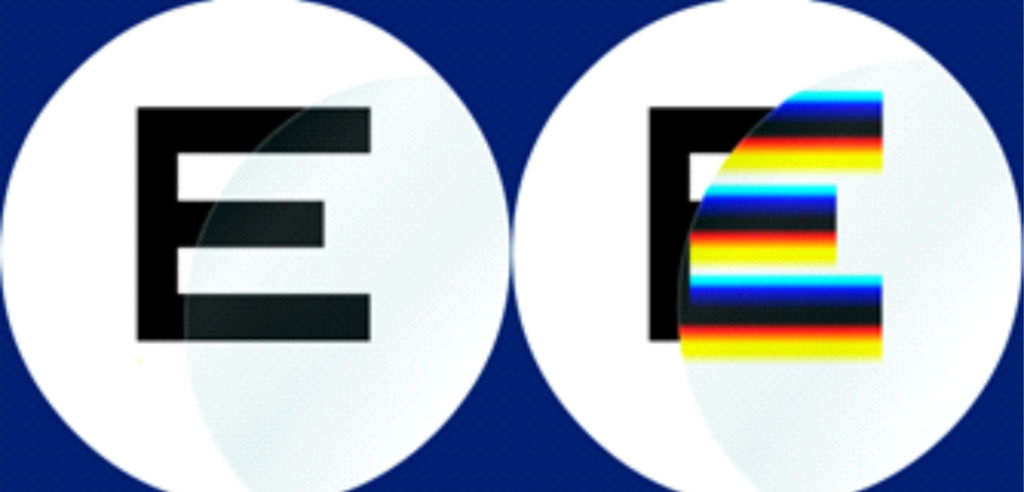

Fonte: Lentes Luxxor

A solução para esse problema já era de certa forma conhecida: um telescópio refletor, que usasse um espelho esférico para captar imagens ao invés de uma série de lentes convexas. Tinha-se a ideia na mão, mas ninguém tinha conseguido montar um telescópio desses que funcionasse até então.  
Em 1668, 58 anos depois do telescópio de Kepler, Newton havia coneguido montar seu primeiro telescópio refletor com sucesso.  
Teoricamente ele é simples, consiste de um espelho esférico côncavo que capturava a luz e então refletia essa imagem num espelho plano que, por último, refletia na lente ocular, mas montar na prática tende a ser complexo.

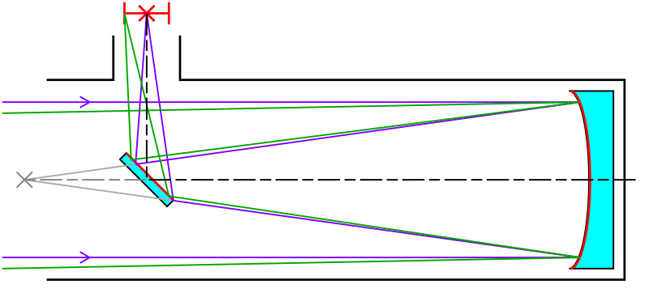

Fonte: Wikimedia Commons, trabalho original por Krishnavedala

Assim como na história da luz, eu também acelerei bastante a linha do tempo, a fim de contar apenas o que foi importante e deixar clara a ideia principal do telescópio: é uma ferramenta feita utilizando-se um conjunto (também chamado “jogo”) de lentes ou espelhos, a fim de ampliar um corpo distante.

## 2.0.3. O que são lentes?

[figure not shown]

Fonte: Love Hina, Vol. III HINATA 016. *"Birth of the Tokyo University Couple!"*

As lentes são peças que interagem com a luz — chamadas formalmente de sistemas ópticos — utilizadas para produzir desvios nos raios de luz que incidem sobre elas, se “aproveitando” da propriedade da refração presente na luz, a fim de concentrá-los em um ponto específico — como em lentes de óculos, por exemplo.

Lentes que fazem os raios paralelos ao seu eixo central se aproximarem dele ainda mais são chamadas “lentes *convergentes*”, pois convergem os raios em um único ponto, já lentes que fazem com que esses raios se afastem de seu eixo central são chamadas “lentes *divergentes*”, pois divergem os raios para outro ponto. As propriedades que realmente ditam como a luz deve ser refratada são a sua geometria e seu índice de refração e, diga-se de passagem, o famigerado “grau” é a capacidade defletir os raios, chamada de diotropia.  
As lentes dividem-se em duas classificações gerais: côncavas e convexas, que são, respectivamentente, lentes de bordas grossas e bordas finas.

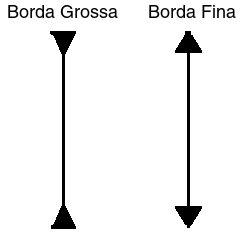

Fonte: Imagem autoral

Existem seis formatos/classificações de lentes, que são nomeadas a partir de um observador externo, que observa suas faces, e que podem ser *côncavas* ou *convexas*.

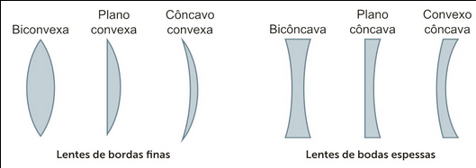

Fonte: CNEC Física - 2ª Série do Ensino Médio Vol. III

Cada classificação tem uma capacidade de desviar os raios de luz, essa capacidade é explicada pela equação dos fabricantes de lentes (também conhecida como “equação de Halley”).

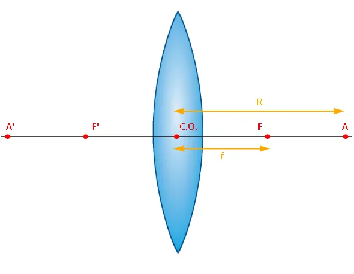

Fonte: Mundo Educação - UOL

Toda lente esférica, independente da classificação, têm essas variáveis em comum:

- centro (*O*);
- foco principal do objeto (*F*);
- foco principal da imagem (*F^I*);
- foco antiprincipal do objeto (também conhecido como centro de curvatura em espelhos esféricos) (*C*);
- foco antiprincipal do objeto (também conhecido como centro de curvatura em espelhos esféricos) (*C^I*);

Essas variáveis são usadas para tudo que envolva algum tipo de cálculo dentro desse assunto. Normalmente — para não dizer “sempre” — os cálculos se baseiam em proporções ou razões.  
Um exemplo é o cálculo de dioptria, que é feito usando uma razão de $\frac{1}{f}$, onde *f* é a distância focal (distância entre o centro *O* e o foco principal do objeto *F*):  
**Nota**: É medido em *di*, não é uma variável especial.  
$\large{C = \frac{1}{f} \textit{di} }$

Outra fórmula usada é a fórmula da ampliação, que é uma razão de $\frac{i}{o}$, onde *i* é o tamanho da imagem e *o* é o tamanho do objeto:  
$\large{A = \frac{i}{o}}$

E, por último, temos a equação de Gauss, também chamada de equação dos pontos conjugados, baseado nos raios notáveis, onde *f* é a distância focal, $p^{o}$ é a posição do objeto e $p^{i}$ é a posição da imagem, normalmente em centímetros ou metros em relação ao centro óptico:

$\large{\frac{1}{f} = \frac{1}{p^o} + \frac{1}{p^i}}$

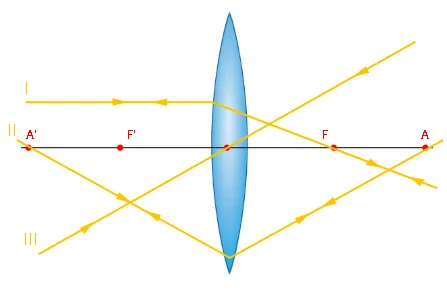

Fonte: Mundo Educação - UOL

Algo que vale se lembrar (ou notar) é que essas fórmulas — assim como algumas regras — são “importadas” dos espelhos esféricos.

## 2.0.4. O Côncavo e o Convexo

[figure not shown]

Fonte: Love Hina, Vol. IV HINATA 027. *"Kendo Girl’s Tiny Little Problem"*

Nessa imagem, retirada do mangá *“Love Hina”*, podemos ver uma garota se observando num espelho de corpo **aparentemente** plano, mas vemos que sua imagem aparece menor no espelho do que na prática — algo que não aconteceria caso o espelho fosse realmente plano — ou seja, esse espelho é esférico e podemos deduzir que tem um raio de curvatura pequeno.

Mas o que esse espelho seria? Côncavo ou convexo?  
Essa é uma dúvida que muitas vezes bate em você como um caminhão de bombeiro bate numa motocicleta em uma autoestrada no meio de uma avaliação.

> “Espera, o foco é positivo ou negativo? Me disseram que o espelho é côncavo no enunciado…”

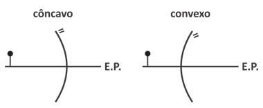

Fonte: Proenem

De fato, a garota está em frente a um espelho convexo, onde a camada que reflete os raios de luz é externa à “calota”, pois sua imagem está sendo **diminuída**.  
Em um espelho côncavo, onde a camada que reflete os raios de luz é interna à “calota”, sua imagem estaria sendo ampliada.

# 3.0. Conclusão

Neste trabalho nós observamos e exploramos não só o contexto histórico do telescópio, mas também da óptica no geral, além de reforçarmos teoricamente conceitos importantes como os de espelhos esféricos.

### 3.0.1 Detalhes técnicos

Este trabalho foi feito usando o [Pandoc](https://pandoc.org/), uma ferramenta de código-aberto para UNIX e Microsoft Windows que permite escrever [Markdown](https://daringfireball.net/projects/markdown/) e [$\rm\LaTeX$](https://www.latex-project.org/) simultaneamente; também foi feito com o uso de ferramentas de linha de comando do UNIX, como `sed`, `grep`, `find`, o editor de texto Vim e a suite ImageMagick.  
Tudo que fora feito de forma autoral por mim, Luiz Antônio, está na licença Creative Commons Attribution 4.0, análoga a domínio público, com a exceção de créditos apenas.